# DS Bootcamp in R Module 2 assignment

Elizaveta Liliom

data scientist in Infostud

08-Apr-2020

## Task 1

**Examine the structure of the data**

Let us have a look at data using `glimpse()` function.

```r
glimpse(olympic)
```

```
## Observations: 271,116
## Variables: 15
## $ ID     <int> 1, 2, 3, 4, 5, 5, 5, 5, 5, 5, 6, 6, 6, 6, 6, 6, 6, 6, 7, 7, ...
## $ Name   <fct> A Dijiang, A Lamusi, Gunnar Nielsen Aaby, Edgar Lindenau Aab...
## $ Sex    <fct> M, M, M, M, F, F, F, F, F, F, M, M, M, M, M, M, M, M, M, M, ...
## $ Age    <int> 24, 23, 24, 34, 21, 21, 25, 25, 27, 27, 31, 31, 31, 31, 33, ...
## $ Height <int> 180, 170, NA, NA, 185, 185, 185, 185, 185, 185, 188, 188, 18...
## $ Weight <dbl> 80, 60, NA, NA, 82, 82, 82, 82, 82, 82, 75, 75, 75, 75, 75, ...
## $ Team   <fct> China, China, Denmark, Denmark/Sweden, Netherlands, Netherla...
## $ NOC    <fct> CHN, CHN, DEN, DEN, NED, NED, NED, NED, NED, NED, USA, USA, ...
## $ Games  <fct> 1992 Summer, 2012 Summer, 1920 Summer, 1900 Summer, 1988 Win...
## $ Year   <int> 1992, 2012, 1920, 1900, 1988, 1988, 1992, 1992, 1994, 1994, ...
## $ Season <fct> Summer, Summer, Summer, Summer, Winter, Winter, Winter, Wint...
## $ City   <fct> Barcelona, London, Antwerpen, Paris, Calgary, Calgary, Alber...
## $ Sport  <fct> Basketball, Judo, Football, Tug-Of-War, Speed Skating, Speed...
## $ Event  <fct> "Basketball Men's Basketball", "Judo Men's Extra-Lightweight...
## $ Medal  <fct> NA, NA, NA, Gold, NA, NA, NA, NA, NA, NA, NA, NA, NA, NA, NA...
```

## Task 2

**Select variables that end with letter t and start with letter S**

1. End with letter t
2. Start with letter s
3. Start with letter s and end with letter t

##### 1.

```r
olympic %>%
select(ends_with("t")) %>%
head(5)
```

| Height | Weight | Sport | Event |
| --- | --- | --- | --- |
| 180 | 80 | Basketball | Basketball Men’s Basketball |
| 170 | 60 | Judo | Judo Men’s Extra-Lightweight |
| NA | NA | Football | Football Men’s Football |
| NA | NA | Tug-Of-War | Tug-Of-War Men’s Tug-Of-War |
| 185 | 82 | Speed Skating | Speed Skating Women’s 500 metres |

##### 2.

```r
olympic %>%
select(starts_with("s")) %>%
head(5)
```

| Sex | Season | Sport |
| --- | --- | --- |
| M | Summer | Basketball |
| M | Summer | Judo |
| M | Summer | Football |
| M | Summer | Tug-Of-War |
| F | Winter | Speed Skating |

##### 3.

```r
olympic %>%
select(starts_with("s") & ends_with("t")) %>%
head(5)
```

| Sport |
| --- |
| Basketball |
| Judo |
| Football |
| Tug-Of-War |
| Speed Skating |

## Task 3

**Create Body Mass Index variable**

```r
olympic %>%
mutate(BMI=Weight/(Height/100)^2) %>%
select(Name,Team,BMI) %>%
head(5)
```

| Name | Team | BMI |
| --- | --- | --- |
| A Dijiang | China | 24.69136 |
| A Lamusi | China | 20.76125 |
| Gunnar Nielsen Aaby | Denmark | NA |
| Edgar Lindenau Aabye | Denmark/Sweden | NA |
| Christine Jacoba Aaftink | Netherlands | 23.95909 |

## Task 4

**Filter from data:**

1. Only Serbian teams and save it as OlympicSR
2. Only Serbian teams from 2000 onward and save it as OlympicSR21c
3. Athletes whose weight is bigger than 100kg and height is over 2m

##### 1.

```r
olympicSR <- olympic %>%
filter(Team == "Serbia")
olympicSR %>%
head(5) %>%
select(Name,Team,Games)
```

| Name | Team | Games |
| --- | --- | --- |
| Aleksandar Aleksi | Serbia | 2012 Summer |
| Milan Aleksi | Serbia | 2012 Summer |
| Milan Aleksi | Serbia | 2016 Summer |
| Andrea Arsovi | Serbia | 2012 Summer |
| Andrea Arsovi | Serbia | 2012 Summer |

##### 2.

```r
olympicSR21c <- olympic %>%
filter(Team == "Serbia" & Year >= 2000)
olympicSR21c %>%
head(5) %>%
select(Name,Team,Games)
```

| Name | Team | Games |
| --- | --- | --- |
| Aleksandar Aleksi | Serbia | 2012 Summer |
| Milan Aleksi | Serbia | 2012 Summer |
| Milan Aleksi | Serbia | 2016 Summer |
| Andrea Arsovi | Serbia | 2012 Summer |
| Andrea Arsovi | Serbia | 2012 Summer |

##### 3.

```r
olympic %>%
filter(Weight > 100 & Height > 200) %>%
select (Name,Height,Weight) %>%
head(5)
```

| Name | Height | Weight |
| --- | --- | --- |
| Julius Shareef Abdur-Rahim | 202 | 104 |
| Essameldin Abou El-Nein | 205 | 102 |
| Kieron Robert Achara | 208 | 110 |
| Roberto Acua | 208 | 109 |
| Constantin Adam | 202 | 105 |

## Task 5

**Arrange Serbian athletes in olympicSR21c data frame by Height in:**

1. ascending order
2. descending order

##### 1.

```r
olympicSR21c %>%
arrange(Height) %>%
select(Name,Games,Height) %>%
head(5)
```

| Name | Games | Height |
| --- | --- | --- |
| Olivera Moldovan | 2012 Summer | 158 |
| Olivera Moldovan | 2016 Summer | 158 |
| Olivera Moldovan | 2016 Summer | 158 |
| Ivana Maksimovi-Anui | 2012 Summer | 161 |
| Ivana Maksimovi-Anui | 2012 Summer | 161 |

##### 2.

```r
olympicSR21c %>%
arrange(desc(Height)) %>%
select(Name,Games,Height) %>%
head(5)
```

| Name | Games | Height |
| --- | --- | --- |
| Miroslav Raduljica | 2016 Summer | 213 |
| Vladimir timac | 2016 Summer | 211 |
| Stefan Birevi | 2016 Summer | 210 |
| Nikola Joki | 2016 Summer | 209 |
| Saa Starovi | 2008 Summer | 207 |

## Task 6

**Using olympicSR df find:**

1. the youngest athlete
2. the heaviest athlete

##### 1.

```r
olympicSR %>%
arrange(Age) %>%
select(Name,Games,Age) %>%
head(1)
```

| Name | Games | Age |
| --- | --- | --- |
| Anja Crevar | 2016 Summer | 16 |

##### 2.

```r
olympicSR %>%
arrange(desc(Weight)) %>%
select(Name,Games,Weight) %>%
head(1)
```

| Name | Games | Weight |
| --- | --- | --- |
| Asmir Kolainac | 2008 Summer | 140 |

## Task 7

**Use summarise():**

1. to print out a summary of olympicSR df containing two variables: max_Age and max_BMI
2. to print out a summary of olympicSR df containing two variables: mean_Age and mean_BMI

##### 1.

```r
olympicSR %>%
mutate(BMI=Weight/(Height/100)^2) %>%
summarise(max_Age = max(Age), max_BMI = max(BMI))
```

| max_Age | max_BMI |
| --- | --- |
| 46 | 40.03546 |

##### 2.

```r
olympicSR %>%
mutate(BMI=Weight/(Height/100)^2) %>%
summarise(mean_Age = mean(Age), mean_BMI = mean(BMI))
```

| mean_Age | mean_BMI |
| --- | --- |
| 26.38918 | 23.34068 |

## Task 8

**Find the number of medals per each team.**

1. Show the results in datatable
2. Visualize your finding

##### 1.

*NOC was chosen instead of Team due to strange “duplications” like Austria, Austria-1 etc.*

```r
olympic %>%
  filter(!is.na(Medal)) %>%
  group_by(NOC,Medal) %>%
  summarize(cases=n()) %>%
  DT::datatable()
```

|  | NOC | Medal | cases |
| --- | --- | --- | --- |
| 1 | AFG | Bronze | 2 |
| 2 | AHO | Silver | 1 |
| 3 | ALG | Bronze | 8 |
| 4 | ALG | Gold | 5 |
| 5 | ALG | Silver | 4 |
| 6 | ANZ | Bronze | 5 |
| 7 | ANZ | Gold | 20 |
| 8 | ANZ | Silver | 4 |
| 9 | ARG | Bronze | 91 |
| 10 | ARG | Gold | 91 |

[output cut: 352 more lines]

##### 2.

Due to the number of data (countries, medals, games) it was decided to visualize the total number of medals per country on the world map (like population). The data set was restricted to Year>2007 due to changes in borders of some countries in the 1990-2000th.

*Note: some countries have different name coding in the olympic table and in the shapefile I got (Algeria: ALG vs DZA). This could be the further improvement for this visualization.*

```r
world <- "ne_50m_admin_0_countries.shp"

world_countries <- st_read(world)
```

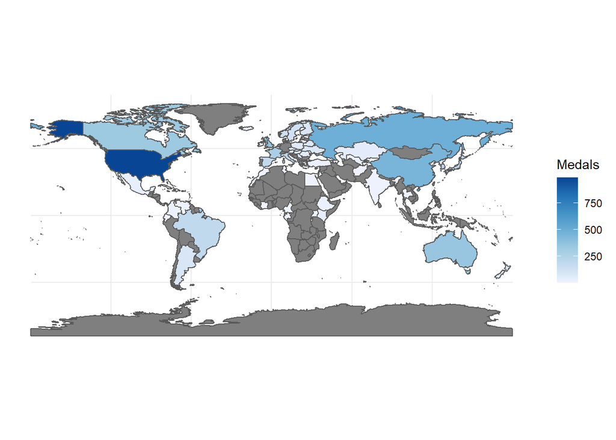

```r
olympic_medals <- olympic %>%
  filter(Year > 2007) %>%
  filter(!is.na(Medal)) %>%
  group_by(NOC) %>%
  summarise(cases=n())

total_medals <- olympic_medals %>%
  summarize(sum(cases))

countries_medals <- left_join(world_countries, olympic_medals,by=c("ADM0_A3"="NOC" ))

ggplot(countries_medals) +
geom_sf(aes(fill=cases)) +
  scale_fill_distiller(direction = 1, name = "Medals")
```